# NTOLab13

4/16/2019

#### Arie’s Subquestion

- Question: Is there a correlation between completion of primary school and the gender ratio of mean years in school in 1999 and 2015? This question is important and interesting because this will show the how gender equality differs by country, and help us understand why this is happening.
- Null hypotheises: There is not a significant correlation between gender ratio of mean years in school and primary school completion, there is not difference by country.
- Alternative hypotheises: There is a significant correlation between gender ratio of mean years in school and primary school completion, there is a difference by country.

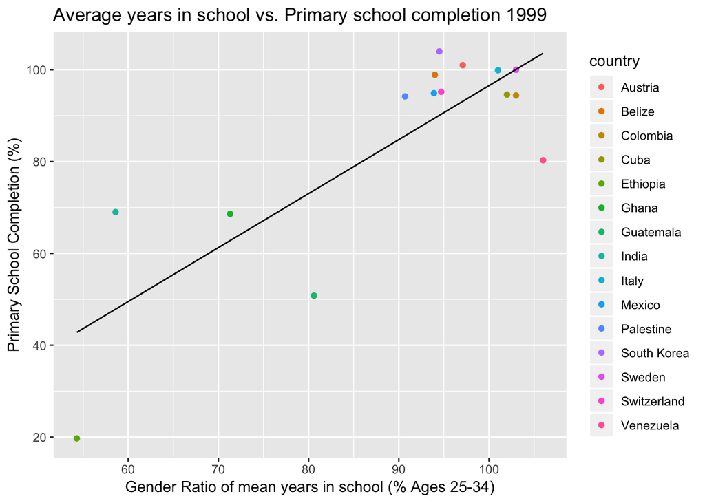

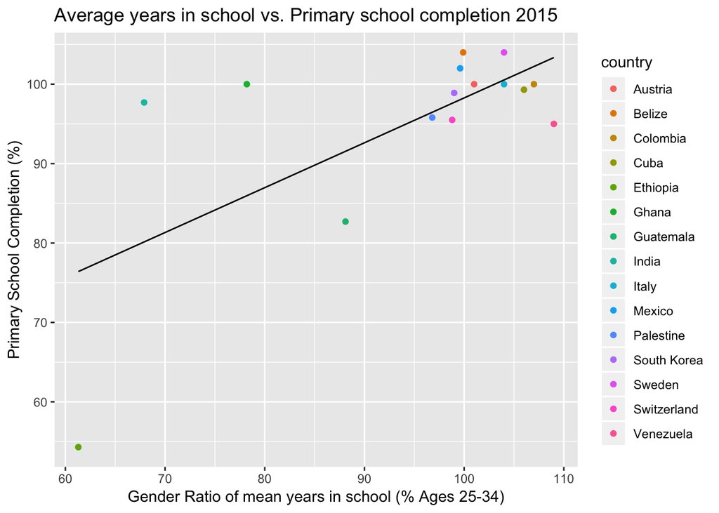

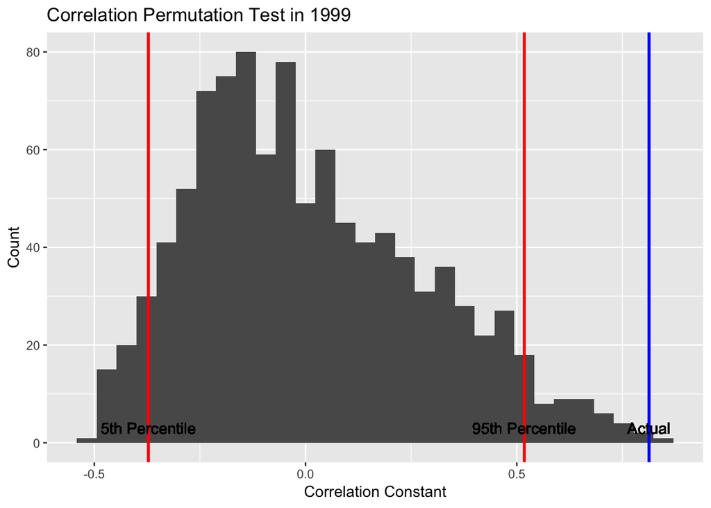

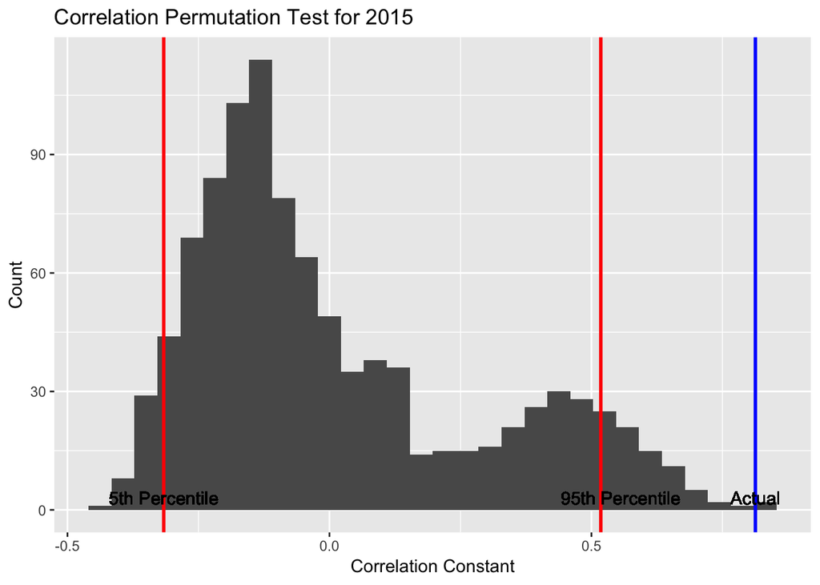

```r
### Function ###
Q2 <- Q%>%
  select(-country)

fun <-function(df,sd){
  dg <- map_dbl(df,sd)

  dg

}

fun(Q2, sd)
```

```
##   1999.x   2015.x   1999.y   2015.y
## 16.21304 14.48277 23.45085 12.41970
```

#### Ethan’s Subquestion

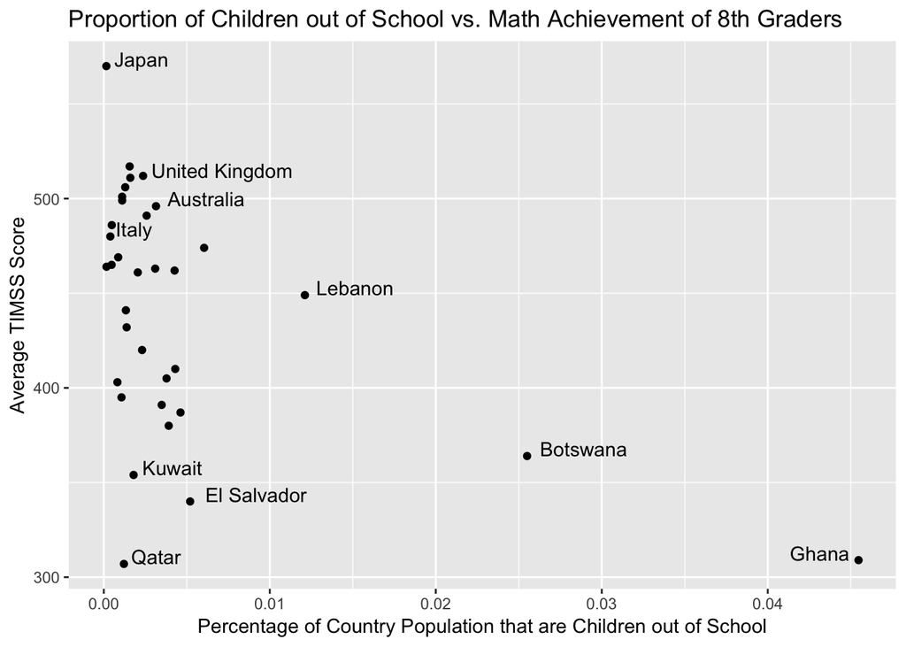

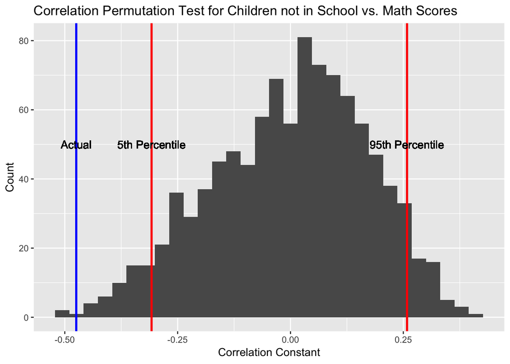

```r
relevant_stats <- function(df, stat_type){

  if (stat_type == "spread") {

    type1 <- "Standard Deviation(s)"
    output1 <- map_dbl(df, sd)
    type2 <- "Inter-Quartile Range(s)"
    output2 <- map_dbl(df, IQR)
    list(type1, output1, type2, output2)

  } else if (stat_type == "average") {

    type1 <- "Median(s)"
    output1 <- map_dbl(df, median)
    type2 <- "Mean(s)"
    output2 <- map_dbl(df, mean)
    list(output1, output2)

  } else if (stat_type == "extreme") {

    type1 <- "Max(s)"
    output1 <- map_dbl(df, max)
    type2 <- "Min(s)"
    output2 <- map_dbl(df, min)
    list(type1, output1, type2, output2)

  } else {

    output1 <- "Please Enter a Known Stat Type (spread, average, extreme)"
    output1
  }


}
```

[output not shown]

#### Anderson’s Subquestion

[figure not shown]

[figure not shown]

```r
dubs2 <- new1 %>%
  select(-country)

banderson <- function(df) {
  x <- map_dbl(df, mean)
  y <- map_dbl(df, sd)
  output <- list(x,y)
  output

}

banderson(dubs2)
```

```
## [[1]]
## X2010.x X2011.x X2010.y X2011.y
##   86.96   87.44   80.36   81.73
##
## [[2]]
##  X2010.x  X2011.x  X2010.y  X2011.y
## 16.28382 16.55873 22.81428 21.87216
```

- The question I was trying to find out is the correlation between the literacy rate of men and women in the years 2010 and 2011.
- From my permutation correlation studies I see that the data in both graphs is significant. The actual findings were past the 95th percentile and therefore the correlation of the literacy rate is significant.
- I can conclude that the correlation of women and men from 10 various countries is significant. The rise of their literacy rates is significant data and the correlation of 0.97 which is from our results is positive.
- The function uses map_dbl to output both the standard deviations and means for each column the the dataset. This is relevant because the two stats go hand-in-hand.

#### David’s Subquestion

Is there a coorelation between the percent of money goverment spends on higher level education and the average income of a person on a global level??

Null Hypothesis: There is no correlation between the percent of money goverments spent on higher education and the average income of a person on a global level.

Alternative Hypothesis: There is correlation between the percent of money goverments spent on higher education and the average income of a person on a global level.

- The test statistic is correlation

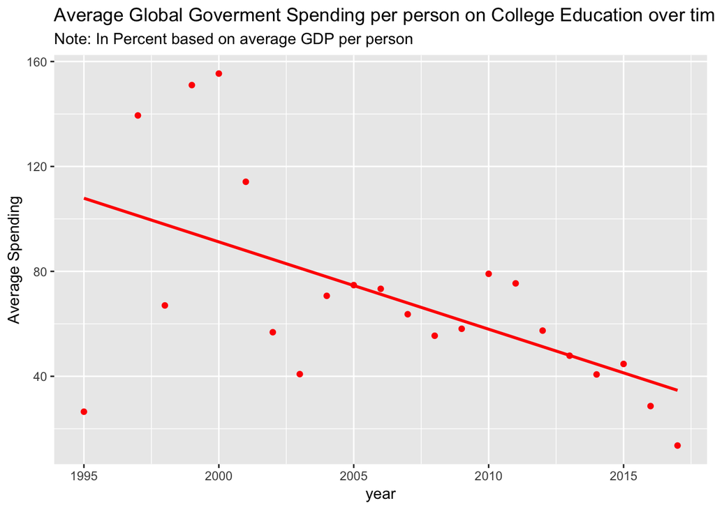

- The graph above shows the average amount of money the goverments spend on college education per person. The average is in terms of percent. Percent = money spend by countries on education per person/ average GDP per person. The graph shows a negative trend as the years go by.

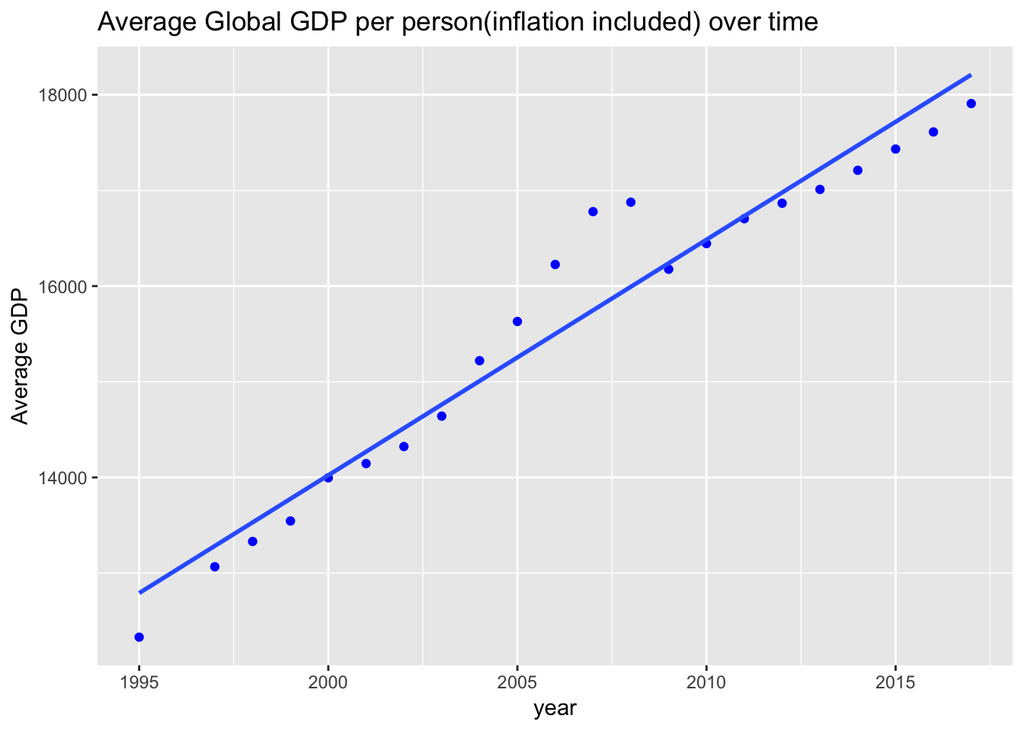

- The graph above shows the average GDP per person. There is an upward trend with the average GDP. This makes sense. As technology advances throughout kthe world, it drives economic growth.

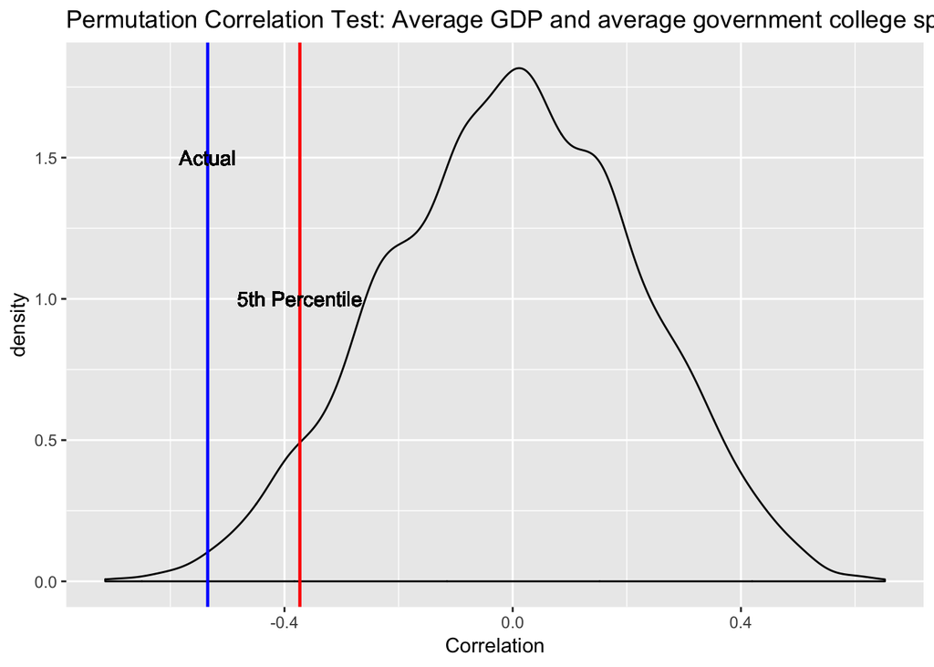

- To explain the connection between goverment spending and GDP, the followoing analogy is helpfull. If a band were to cover 40% of your ticket then you will only pay the other 60%. However if they say they will cover $50 of your ticket. Has inflation rises, they will cover less and less of your ticket. This seems to be the same trend with goverment funding to colleges. The percent of college funding is decreasing while the income is increasing. This seems like goverments are spending a fixed amount even though thier average income per person is increasing.
- The correlation between income and gov spending on college is negative and its significant occording to the permutation correlation test.The correlation of -.53 is statistically significant since it lies in the bottom 5th percentile.

```r
mapp <- function(data){
data <- data[-1]
  mean = map(data,mean)
  median = map(data,median)
  max = map(data,max)
  min = map(data,min)

x <- as.tibble(mean)
x1 <- as.tibble(median)
x3 <- as.tibble(min)
x4 <-as.tibble(max)
x5 <- c("mean","median","min","max")

y1 <- full_join(x,x1)
y2 <- full_join(x3,x4)
yote <- full_join(y1,y2) %>% mutate(map_type = x5)
yote <- yote[c(3,2,1)]

print(yote)
 }

mapp(GDP)
```

```
## # A tibble: 4 x 3
##   map_type  income  year
##   <chr>      <dbl> <dbl>
## 1 mean       6393.  1920
## 2 median     1640   1920
## 3 min         247   1800
## 4 max      182000   2040
```

```r
mapp(cost)
```

```
## # A tibble: 4 x 3
##   map_type    cost  year
##   <chr>      <dbl> <dbl>
## 1 mean       71.7  2007.
## 2 median     30.4  2008
## 3 min         2.85 1995
## 4 max      2530    2017
```

#### Ryan’s Subquestion

Subquestion: What is the correlation between gender ratio in primary and secondary school and the HDI index for a country?

This contributes to answering the overall question because it incorporates the overarching theme of education and how it relates to other sectors of a country.

Null hypothesis: There is a significant correlation between the ratio of boys to girls in primary and secondary school and the HDI index of a country

Alternative hypothesis: There is not a significant correlation between the ratio of boys to girls in primary and secondary school and the HDI index of a country.

The test statistic is the correlation.

```r
funk <- function(df, fun) {
  out <- vector("double", length(df))
  for (i in seq_along(df)) {
    out[i] <- fun(df[[i]])
  }
  out
}

merged1 <- merged %>% transmute(hdi = hdi_2015, ratio = ratio_2015)
funk(merged1, sd) #find standard deviation of hdi and ratio
```

```
## [1] 0.16079952 0.07332416
```

```r
hdi1 <-merged1$hdi
```

The function above finds the standard deviation of HDI index and ratio.

[output not shown]

[figure not shown]

[figure not shown]

- Since the actual correlation is greater than the 95th percentile we can conclude the the data is significant and that there is a correlation

#### Who Did What

- David - individual section, general edits, helped resolve gitKraken merge errors.
- Arie -
- Anderson - Individual Section
- Ethan - Individual Section, Anderson function
- Ryan - Individual section